# Number of cigarettes

### 2.9.2 Wave 2

#### 2.9.2.1 Study-specific variable description

| **Name** | `f_PCIGDOSE` |
| --- | --- |
| **Label** | `amount smoked` |
| **Table name** | `1066-UrbanMexico-Followup` |
| **Categories** | `continuous` |
| **Missings** | `NA` |
| **Description** |  |

f_PCIGDOSE

| Sample size | Missing values |
| --- | --- |
| 749 | 688 |

Summary

| Min. | 1st Qu. | Median | Mean | 3rd Qu. | Max. | NA’s |
| --- | --- | --- | --- | --- | --- | --- |
| 1 | 3 | 4 | 5.918 | 7 | 60 | 688 |

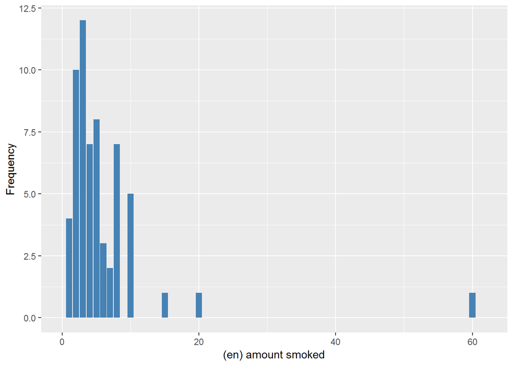

#### 2.9.2.2 Harmonisation algorithm

To compute the harmonize variable from the study-specific variable it has to be recoded as follows:

- `f_PCIGDOSE*7`
- `NA into 999`

```r
t1066_ds_UM_w2 <- tibble(id = t1066_UM_w2$id)
t1066_ds_UM_w2$n_cigarettes <- Recode(t1066_UM_w2$f_PCIGDOSE * 7, "NA = '999' ")
t1066_ds_UM_w2$n_cigarettes <- labelled(t1066_ds_UM_w2$n_cigarettes, labels = c(Missing = 999,
    Do_not_know = 998, Refuse = 997, Not_applicable = 996, Does_not_answer = 995,
    Not_attempt_not_done = 994, Disable_to_measure = 993, Impute = 992, CAPI_interviewer_error = 991))
```

#### 2.9.2.3 Statistical description of the new harmonised variable

Number of cigarettes smoked per week

| Sample size | Missing values |
| --- | --- |
| 749 | 688 |

Values

|  | No-missings | 991 | 992 | 993 | 994 | 995 | 996 | 997 | 998 | 999 | NA |
| --- | --- | --- | --- | --- | --- | --- | --- | --- | --- | --- | --- |
| Frequency | 61.00 | 0 | 0 | 0 | 0 | 0 | 0 | 0 | 0 | 688.00 | 0 |
| Percentage | 8.14 | 0 | 0 | 0 | 0 | 0 | 0 | 0 | 0 | 91.86 | 0 |

Summary

| Min. | 1st Qu. | Median | Mean | 3rd Qu. | Max. |
| --- | --- | --- | --- | --- | --- |
| 7 | 21 | 28 | 41.43 | 49 | 420 |

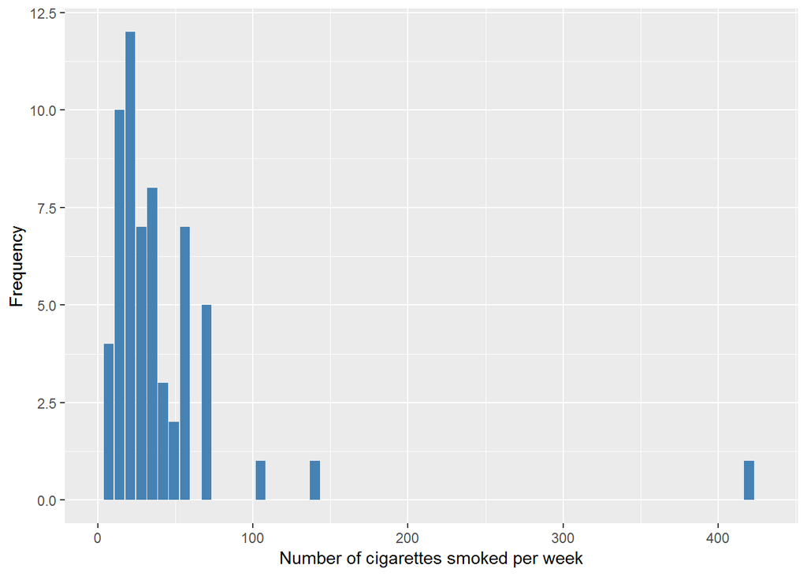

#### 2.9.2.4 Validation

[output not shown]

## 2.10 Rural Mexico

### 2.10.1 Wave 1

#### 2.10.1.1 Study-specific variable description

| **Name** | `PCIGDOSE` |
| --- | --- |
| **Label** | `amount smoked` |
| **Table name** | `1066-RuralMexico-Baseline` |
| **Categories** | `continuous` |
| **Missings** | `NA` |
| **Description** |  |

PCIGDOSE

| Sample size | Missing values |
| --- | --- |
| 1000 | 738 |

Summary

| Min. | 1st Qu. | Median | Mean | 3rd Qu. | Max. | NA’s |
| --- | --- | --- | --- | --- | --- | --- |
| 1 | 2 | 3 | 7.649 | 7.75 | 60 | 738 |

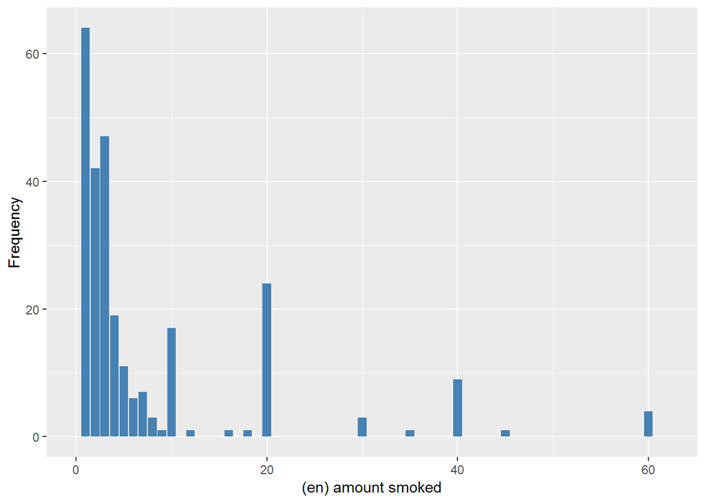

#### 2.10.1.2 Harmonisation algorithm

To compute the harmonize variable from the study-specific variable it has to be recoded as follows:

- `PCIGDOSE*7`
- `NA into 999`

```r
t1066_ds_RM_w1 <- tibble(id = t1066_RM_w1$id)
t1066_ds_RM_w1$n_cigarettes <- Recode(t1066_RM_w1$PCIGDOSE * 7, "NA = '999' ")
t1066_ds_RM_w1$n_cigarettes <- labelled(t1066_ds_RM_w1$n_cigarettes, labels = c(Missing = 999,
    Do_not_know = 998, Refuse = 997, Not_applicable = 996, Does_not_answer = 995,
    Not_attempt_not_done = 994, Disable_to_measure = 993, Impute = 992, CAPI_interviewer_error = 991))
```

#### 2.10.1.3 Statistical description of the new harmonised variable

Number of cigarettes smoked per week

| Sample size | Missing values |
| --- | --- |
| 1000 | 738 |

Values

|  | No-missings | 991 | 992 | 993 | 994 | 995 | 996 | 997 | 998 | 999 | NA |
| --- | --- | --- | --- | --- | --- | --- | --- | --- | --- | --- | --- |
| Frequency | 262.0 | 0 | 0 | 0 | 0 | 0 | 0 | 0 | 0 | 738.0 | 0 |
| Percentage | 26.2 | 0 | 0 | 0 | 0 | 0 | 0 | 0 | 0 | 73.8 | 0 |

Summary

| Min. | 1st Qu. | Median | Mean | 3rd Qu. | Max. |
| --- | --- | --- | --- | --- | --- |
| 7 | 14 | 21 | 53.54 | 54.25 | 420 |

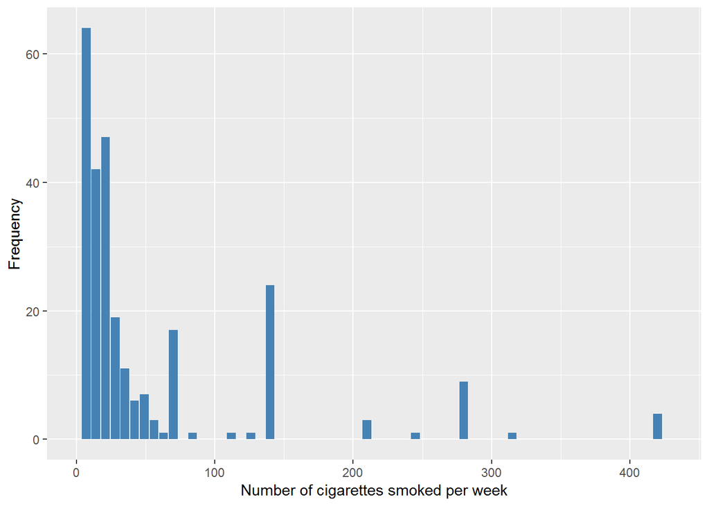

#### 2.10.1.4 Validation

|  | 1->7 | 2->14 | 3->21 | 4->28 | 5->35 | 6->42 | 7->49 | 8->56 | 9->63 | 10->70 | 12->84 | 16->112 | 18->126 | 20->140 | 30->210 | 35->245 | 40->280 | 45->315 | 60->420 | NA->999 |
| --- | --- | --- | --- | --- | --- | --- | --- | --- | --- | --- | --- | --- | --- | --- | --- | --- | --- | --- | --- | --- |
| BeforeH | 64 | 42 | 47 | 19 | 11 | 6 | 7 | 3 | 1 | 17 | 1 | 1 | 1 | 24 | 3 | 1 | 9 | 1 | 4 | 738 |
| AfterH | 64 | 42 | 47 | 19 | 11 | 6 | 7 | 3 | 1 | 17 | 1 | 1 | 1 | 24 | 3 | 1 | 9 | 1 | 4 | 738 |

### 2.10.2 Wave 2

#### 2.10.2.1 Study-specific variable description

| **Name** | `f_PCIGDOSE` |
| --- | --- |
| **Label** | `amount smoked` |
| **Table name** | `1066-RuralMexico-Followup` |
| **Categories** | `continuous` |
| **Missings** | `NA` |
| **Description** |  |

f_PCIGDOSE

| Sample size | Missing values |
| --- | --- |
| 713 | 688 |

Summary

| Min. | 1st Qu. | Median | Mean | 3rd Qu. | Max. | NA’s |
| --- | --- | --- | --- | --- | --- | --- |
| 1 | 2 | 2 | 2.84 | 3 | 9 | 688 |

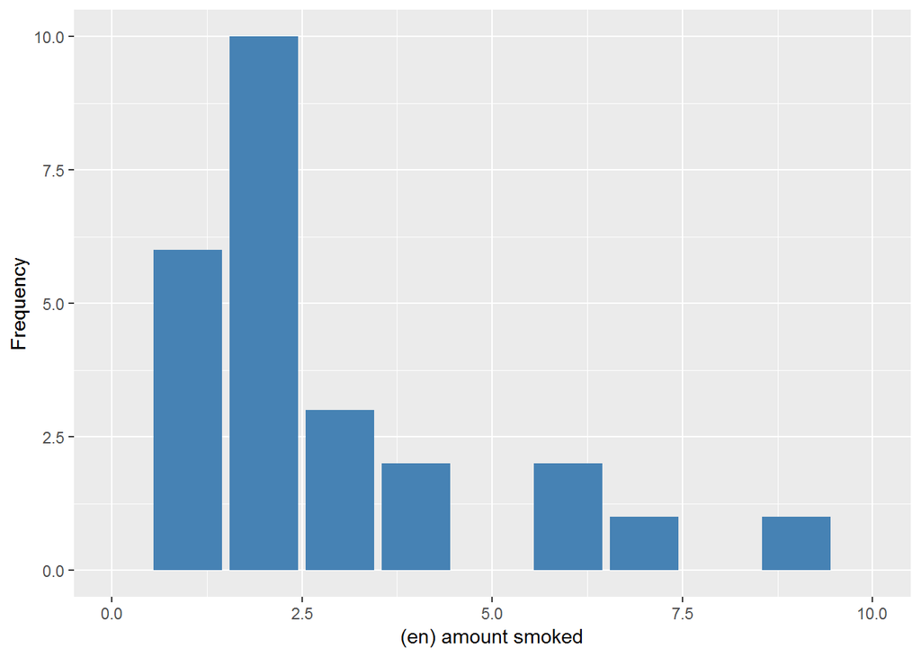

#### 2.10.2.2 Harmonisation algorithm

To compute the harmonize variable from the study-specific variable it has to be recoded as follows:

- `f_PCIGDOSE*7`
- `NA into 999`

```r
t1066_ds_RM_w2 <- tibble(id = t1066_RM_w2$id)
t1066_ds_RM_w2$n_cigarettes <- Recode(t1066_RM_w2$f_PCIGDOSE * 7, "NA = '999' ")
t1066_ds_RM_w2$n_cigarettes <- labelled(t1066_ds_RM_w2$n_cigarettes, labels = c(Missing = 999,
    Do_not_know = 998, Refuse = 997, Not_applicable = 996, Does_not_answer = 995,
    Not_attempt_not_done = 994, Disable_to_measure = 993, Impute = 992, CAPI_interviewer_error = 991))
```

#### 2.10.2.3 Statistical description of the new harmonised variable

Number of cigarettes smoked per week

| Sample size | Missing values |
| --- | --- |
| 713 | 688 |

Values

|  | No-missings | 991 | 992 | 993 | 994 | 995 | 996 | 997 | 998 | 999 | NA |
| --- | --- | --- | --- | --- | --- | --- | --- | --- | --- | --- | --- |
| Frequency | 25.00 | 0 | 0 | 0 | 0 | 0 | 0 | 0 | 0 | 688.00 | 0 |
| Percentage | 3.51 | 0 | 0 | 0 | 0 | 0 | 0 | 0 | 0 | 96.49 | 0 |

Summary

| Min. | 1st Qu. | Median | Mean | 3rd Qu. | Max. |
| --- | --- | --- | --- | --- | --- |
| 7 | 14 | 14 | 19.88 | 21 | 63 |

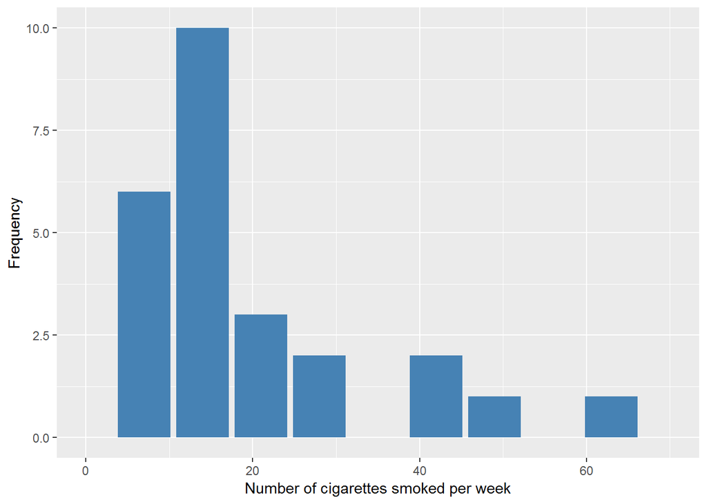

#### 2.10.2.4 Validation

|  | 1->7 | 2->14 | 3->21 | 4->28 | 6->42 | 7->49 | 9->63 | NA->999 |
| --- | --- | --- | --- | --- | --- | --- | --- | --- |
| BeforeH | 6 | 10 | 3 | 2 | 2 | 1 | 1 | 688 |
| AfterH | 6 | 10 | 3 | 2 | 2 | 1 | 1 | 688 |

## 2.11 Puerto Rico

### 2.11.1 Wave 1

#### 2.11.1.1 Study-specific variable description

| **Name** | `PCIGDOSE` |
| --- | --- |
| **Label** | `amount smoked` |
| **Table name** | `1066-PuertoRico-Baseline` |
| **Categories** | `continuous` |
| **Missings** | `NA` |
| **Description** |  |

PCIGDOSE

| Sample size | Missing values |
| --- | --- |
| 2009 | 1461 |

Summary

| Min. | 1st Qu. | Median | Mean | 3rd Qu. | Max. | NA’s |
| --- | --- | --- | --- | --- | --- | --- |
| 1 | 5 | 10 | 18.56 | 20 | 60 | 1461 |

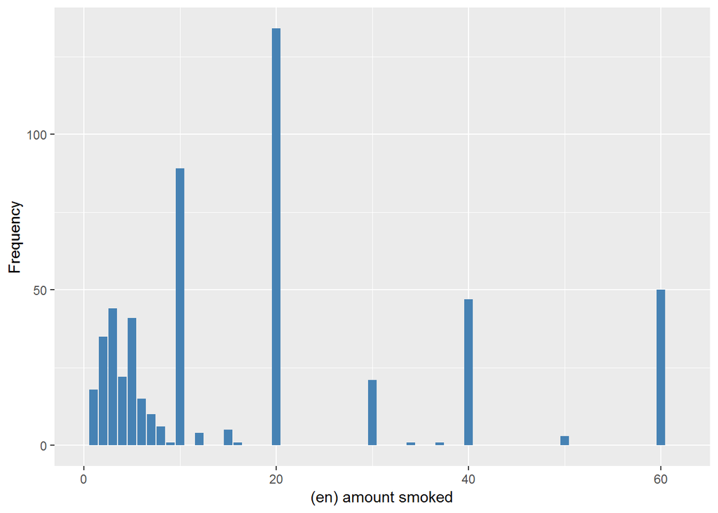

#### 2.11.1.2 Harmonisation algorithm

To compute the harmonize variable from the study-specific variable it has to be recoded as follows:

- `PCIGDOSE*7`
- `NA into 999`

```r
t1066_ds_PR_w1 <- tibble(id = t1066_PR_w1$id)
t1066_ds_PR_w1$n_cigarettes <- Recode(t1066_PR_w1$PCIGDOSE * 7, "NA = '999' ")
t1066_ds_PR_w1$n_cigarettes <- labelled(t1066_ds_PR_w1$n_cigarettes, labels = c(Missing = 999,
    Do_not_know = 998, Refuse = 997, Not_applicable = 996, Does_not_answer = 995,
    Not_attempt_not_done = 994, Disable_to_measure = 993, Impute = 992, CAPI_interviewer_error = 991))
```

#### 2.11.1.3 Statistical description of the new harmonised variable

Number of cigarettes smoked per week

| Sample size | Missing values |
| --- | --- |
| 2009 | 1461 |

Values

|  | No-missings | 991 | 992 | 993 | 994 | 995 | 996 | 997 | 998 | 999 | NA |
| --- | --- | --- | --- | --- | --- | --- | --- | --- | --- | --- | --- |
| Frequency | 548.00 | 0 | 0 | 0 | 0 | 0 | 0 | 0 | 0 | 1461.00 | 0 |
| Percentage | 27.28 | 0 | 0 | 0 | 0 | 0 | 0 | 0 | 0 | 72.72 | 0 |

Summary

| Min. | 1st Qu. | Median | Mean | 3rd Qu. | Max. |
| --- | --- | --- | --- | --- | --- |
| 7 | 35 | 70 | 129.9 | 140 | 420 |

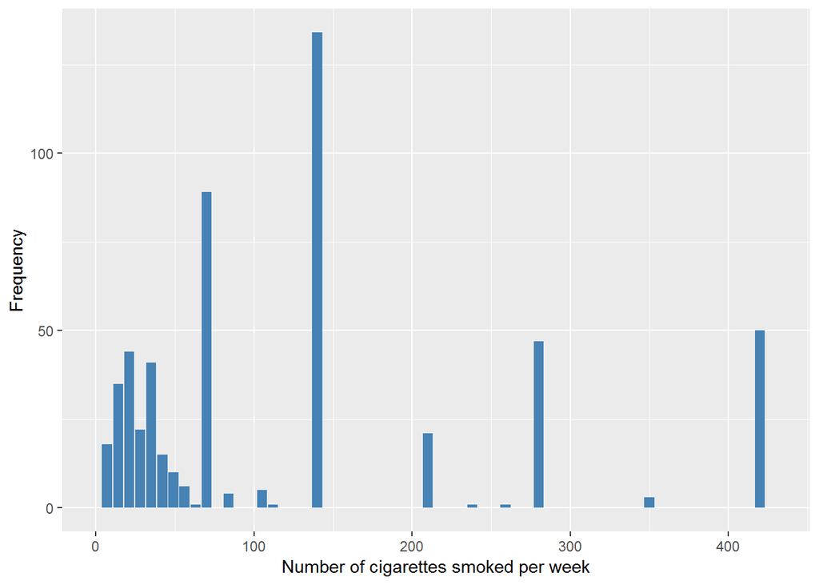

#### 2.11.1.4 Validation

|  | 1->7 | 2->14 | 3->21 | 4->28 | 5->35 | 6->42 | 7->49 | 8->56 | 9->63 | 10->70 | 12->84 | 15->105 | 16->112 | 20->140 | 30->210 | 34->238 | 37->259 | 40->280 | 50->350 | 60->420 | NA->999 |
| --- | --- | --- | --- | --- | --- | --- | --- | --- | --- | --- | --- | --- | --- | --- | --- | --- | --- | --- | --- | --- | --- |
| BeforeH | 18 | 35 | 44 | 22 | 41 | 15 | 10 | 6 | 1 | 89 | 4 | 5 | 1 | 134 | 21 | 1 | 1 | 47 | 3 | 50 | 1461 |
| AfterH | 18 | 35 | 44 | 22 | 41 | 15 | 10 | 6 | 1 | 89 | 4 | 5 | 1 | 134 | 21 | 1 | 1 | 47 | 3 | 50 | 1461 |

### 2.11.2 Wave 2

#### 2.11.2.1 Study-specific variable description

| **Name** | `f_PCIGDOSE` |
| --- | --- |
| **Label** | `amount smoked` |
| **Table name** | `1066-PuertoRico-Followup` |
| **Categories** | `continuous` |
| **Missings** | `NA` |
| **Description** |  |

f_PCIGDOSE

| Sample size | Missing values |
| --- | --- |
| 1265 | 1234 |

Summary

| Min. | 1st Qu. | Median | Mean | 3rd Qu. | Max. | NA’s |
| --- | --- | --- | --- | --- | --- | --- |
| 1 | 3.5 | 10 | 11.68 | 20 | 40 | 1234 |

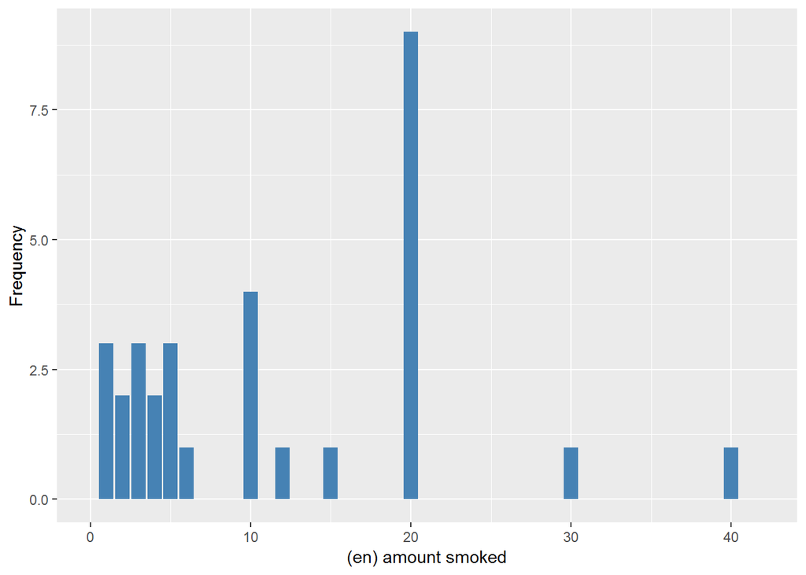

#### 2.11.2.2 Harmonisation algorithm

To compute the harmonize variable from the study-specific variable it has to be recoded as follows:

- `f_PCIGDOSE*7`
- `NA into 999`

```r
t1066_ds_PR_w2 <- tibble(id = t1066_PR_w2$id)
t1066_ds_PR_w2$n_cigarettes <- Recode(t1066_PR_w2$f_PCIGDOSE * 7, "NA = '999' ")
t1066_ds_PR_w2$n_cigarettes <- labelled(t1066_ds_PR_w2$n_cigarettes, labels = c(Missing = 999,
    Do_not_know = 998, Refuse = 997, Not_applicable = 996, Does_not_answer = 995,
    Not_attempt_not_done = 994, Disable_to_measure = 993, Impute = 992, CAPI_interviewer_error = 991))
```

#### 2.11.2.3 Statistical description of the new harmonised variable

Number of cigarettes smoked per week

| Sample size | Missing values |
| --- | --- |
| 1265 | 1234 |

Values

|  | No-missings | 991 | 992 | 993 | 994 | 995 | 996 | 997 | 998 | 999 | NA |
| --- | --- | --- | --- | --- | --- | --- | --- | --- | --- | --- | --- |
| Frequency | 31.00 | 0 | 0 | 0 | 0 | 0 | 0 | 0 | 0 | 1234.00 | 0 |
| Percentage | 2.45 | 0 | 0 | 0 | 0 | 0 | 0 | 0 | 0 | 97.55 | 0 |

Summary

| Min. | 1st Qu. | Median | Mean | 3rd Qu. | Max. |
| --- | --- | --- | --- | --- | --- |
| 7 | 24.5 | 70 | 81.74 | 140 | 280 |

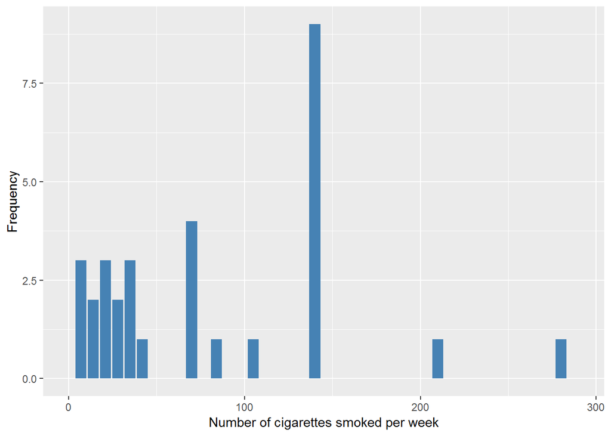

#### 2.11.2.4 Validation

|  | 1->7 | 2->14 | 3->21 | 4->28 | 5->35 | 6->42 | 10->70 | 12->84 | 15->105 | 20->140 | 30->210 | 40->280 | NA->999 |
| --- | --- | --- | --- | --- | --- | --- | --- | --- | --- | --- | --- | --- | --- |
| BeforeH | 3 | 2 | 3 | 2 | 3 | 1 | 4 | 1 | 1 | 9 | 1 | 1 | 1234 |
| AfterH | 3 | 2 | 3 | 2 | 3 | 1 | 4 | 1 | 1 | 9 | 1 | 1 | 1234 |

## 2.12 Summary of descriptive statistics of the harmonised variable accross populations and waves

Number of cigarettes smoked per week

| n_cigarettes | Cuba w1 | India w1 | Urban China w1 | Rural China w1 | Dominican Republic w1 | Venezuela w1 | Urban Peru w1 | Rural Peru w1 | Urban Mexico w1 | Rural Mexico w1 | Puerto Rico w1 |
| --- | --- | --- | --- | --- | --- | --- | --- | --- | --- | --- | --- |
| Min. | 7 | 7 | 7 | 14 | 7 | 7 | 7 | 7 | 7 | 7 | 7 |
| 1st Qu. | 28 | 7 | 49 | 70 | 21 | 14 | 14 | 14 | 14 | 14 | 35 |
| Median | 70 | 21 | 70 | 91 | 42 | 28 | 35 | 31.5 | 28 | 21 | 70 |
| Mean | 108.6 | 44.09 | 101.2 | 96.73 | 83.48 | 66.87 | 70.7 | 86.42 | 62.02 | 53.54 | 129.9 |
| 3rd Qu. | 140 | 70 | 140 | 140 | 140 | 70 | 70 | 140 | 84 | 54.25 | 140 |
| Max. | 420 | 420 | 420 | 420 | 420 | 420 | 420 | 420 | 420 | 420 | 420 |
| No-missings | 1259 | 781 | 274 | 335 | 937 | 792 | 211 | 52 | 336 | 262 | 548 |
| 991 | 0 | 0 | 0 | 0 | 0 | 0 | 0 | 0 | 0 | 0 | 0 |
| 992 | 0 | 0 | 0 | 0 | 0 | 0 | 0 | 0 | 0 | 0 | 0 |
| 993 | 0 | 0 | 0 | 0 | 0 | 0 | 0 | 0 | 0 | 0 | 0 |
| 994 | 0 | 0 | 0 | 0 | 0 | 0 | 0 | 0 | 0 | 0 | 0 |
| 995 | 0 | 0 | 0 | 0 | 0 | 0 | 0 | 0 | 0 | 0 | 0 |
| 996 | 0 | 0 | 0 | 0 | 0 | 0 | 0 | 0 | 0 | 0 | 0 |
| 997 | 0 | 0 | 0 | 0 | 0 | 0 | 0 | 0 | 0 | 0 | 0 |
| 998 | 0 | 0 | 0 | 0 | 0 | 0 | 0 | 0 | 0 | 0 | 0 |
| 999 | 1554 | 1223 | 886 | 667 | 1074 | 1173 | 1170 | 500 | 667 | 738 | 1461 |
| NA | 0 | 0 | 0 | 0 | 0 | 0 | 0 | 0 | 0 | 0 | 0 |
| sample size | 2813 | 2004 | 1160 | 1002 | 2011 | 1965 | 1381 | 552 | 1003 | 1000 | 2009 |

Number of cigarettes smoked per week

| n_cigarettes | Cuba w2 | Urban China w2 | Rural China w2 | Dominican Republic w2 | Venezuela w2 | Urban Peru w2 | Rural Peru w2 | Urban Mexico w2 | Rural Mexico w2 | Puerto Rico w2 |
| --- | --- | --- | --- | --- | --- | --- | --- | --- | --- | --- |
| Min. | 7 | 7 | 7 | 7 | 7 | 7 | 21 | 7 | 7 | 7 |
| 1st Qu. | 21 | 42 | 42 | 14 | 21 | 14 | 28 | 21 | 14 | 24.5 |
| Median | 70 | 70 | 70 | 28 | 42 | 35 | 42 | 28 | 14 | 70 |
| Mean | 75.33 | 76.54 | 79.54 | 49.32 | 64.77 | 54.76 | 54.83 | 41.43 | 19.88 | 81.74 |
| 3rd Qu. | 140 | 105 | 105 | 70 | 70 | 70 | 56 | 49 | 21 | 140 |
| Max. | 280 | 280 | 420 | 420 | 420 | 210 | 140 | 420 | 63 | 280 |
| No-missings | 239 | 121 | 207 | 111 | 99 | 34 | 6 | 61 | 25 | 31 |
| 991 | 0 | 0 | 0 | 0 | 0 | 0 | 0 | 0 | 0 | 0 |
| 992 | 0 | 0 | 0 | 0 | 0 | 0 | 0 | 0 | 0 | 0 |
| 993 | 0 | 0 | 0 | 0 | 0 | 0 | 0 | 0 | 0 | 0 |
| 994 | 0 | 0 | 0 | 0 | 0 | 0 | 0 | 0 | 0 | 0 |
| 995 | 0 | 0 | 0 | 0 | 0 | 0 | 0 | 0 | 0 | 0 |
| 996 | 0 | 0 | 0 | 0 | 0 | 0 | 0 | 0 | 0 | 0 |
| 997 | 0 | 0 | 0 | 0 | 0 | 0 | 0 | 0 | 0 | 0 |
| 998 | 0 | 0 | 0 | 0 | 0 | 0 | 0 | 0 | 0 | 0 |
| 999 | 1768 | 620 | 504 | 1086 | 1158 | 856 | 415 | 688 | 688 | 1234 |
| NA | 0 | 0 | 0 | 0 | 0 | 0 | 0 | 0 | 0 | 0 |
| sample size | 2007 | 741 | 711 | 1197 | 1257 | 890 | 421 | 749 | 713 | 1265 |

# 3 Quality estimation